# Optimal Treatment Analysis

## Outcome Variable

**Outcome Variable:** ever_wasted

## Predictor Variables

**Intervention Variable:** birthlen

**Adjustment Set:**

- arm
- sex
- W_mage
- meducyrs
- feducyrs
- vagbrth
- single
- brthmon
- W_parity
- delta_W_mage
- delta_meducyrs
- delta_feducyrs
- delta_vagbrth
- delta_single
- delta_brthmon
- delta_W_parity

## Stratifying Variables

The analysis was stratified on these variable(s):

- agecat
- studyid
- country

## Data Summary

| agecat | studyid | country | birthlen | ever_wasted | n_cell | n |
| --- | --- | --- | --- | --- | --- | --- |
| 0-24 months (no birth wast) | ki0047075b-MAL-ED | BANGLADESH | >=50 cm | 0 | 23 | 254 |
| 0-24 months (no birth wast) | ki0047075b-MAL-ED | BANGLADESH | >=50 cm | 1 | 6 | 254 |
| 0-24 months (no birth wast) | ki0047075b-MAL-ED | BANGLADESH | <48 cm | 0 | 105 | 254 |
| 0-24 months (no birth wast) | ki0047075b-MAL-ED | BANGLADESH | <48 cm | 1 | 35 | 254 |
| 0-24 months (no birth wast) | ki0047075b-MAL-ED | BANGLADESH | [48-50) cm | 0 | 70 | 254 |
| 0-24 months (no birth wast) | ki0047075b-MAL-ED | BANGLADESH | [48-50) cm | 1 | 15 | 254 |
| 0-24 months (no birth wast) | ki0047075b-MAL-ED | BRAZIL | >=50 cm | 0 | 32 | 188 |
| 0-24 months (no birth wast) | ki0047075b-MAL-ED | BRAZIL | >=50 cm | 1 | 2 | 188 |
| 0-24 months (no birth wast) | ki0047075b-MAL-ED | BRAZIL | <48 cm | 0 | 72 | 188 |
| 0-24 months (no birth wast) | ki0047075b-MAL-ED | BRAZIL | <48 cm | 1 | 6 | 188 |
| 0-24 months (no birth wast) | ki0047075b-MAL-ED | BRAZIL | [48-50) cm | 0 | 72 | 188 |
| 0-24 months (no birth wast) | ki0047075b-MAL-ED | BRAZIL | [48-50) cm | 1 | 4 | 188 |
| 0-24 months (no birth wast) | ki0047075b-MAL-ED | INDIA | >=50 cm | 0 | 17 | 199 |
| 0-24 months (no birth wast) | ki0047075b-MAL-ED | INDIA | >=50 cm | 1 | 8 | 199 |
| 0-24 months (no birth wast) | ki0047075b-MAL-ED | INDIA | <48 cm | 0 | 66 | 199 |
| 0-24 months (no birth wast) | ki0047075b-MAL-ED | INDIA | <48 cm | 1 | 38 | 199 |
| 0-24 months (no birth wast) | ki0047075b-MAL-ED | INDIA | [48-50) cm | 0 | 46 | 199 |
| 0-24 months (no birth wast) | ki0047075b-MAL-ED | INDIA | [48-50) cm | 1 | 24 | 199 |
| 0-24 months (no birth wast) | ki0047075b-MAL-ED | NEPAL | >=50 cm | 0 | 33 | 172 |
| 0-24 months (no birth wast) | ki0047075b-MAL-ED | NEPAL | >=50 cm | 1 | 5 | 172 |
| 0-24 months (no birth wast) | ki0047075b-MAL-ED | NEPAL | <48 cm | 0 | 47 | 172 |
| 0-24 months (no birth wast) | ki0047075b-MAL-ED | NEPAL | <48 cm | 1 | 21 | 172 |
| 0-24 months (no birth wast) | ki0047075b-MAL-ED | NEPAL | [48-50) cm | 0 | 58 | 172 |
| 0-24 months (no birth wast) | ki0047075b-MAL-ED | NEPAL | [48-50) cm | 1 | 8 | 172 |
| 0-24 months (no birth wast) | ki0047075b-MAL-ED | PERU | >=50 cm | 0 | 31 | 285 |
| 0-24 months (no birth wast) | ki0047075b-MAL-ED | PERU | >=50 cm | 1 | 2 | 285 |
| 0-24 months (no birth wast) | ki0047075b-MAL-ED | PERU | <48 cm | 0 | 128 | 285 |
| 0-24 months (no birth wast) | ki0047075b-MAL-ED | PERU | <48 cm | 1 | 13 | 285 |
| 0-24 months (no birth wast) | ki0047075b-MAL-ED | PERU | [48-50) cm | 0 | 106 | 285 |
| 0-24 months (no birth wast) | ki0047075b-MAL-ED | PERU | [48-50) cm | 1 | 5 | 285 |

[output cut: 474 more lines]

The following strata were considered:

- agecat: 0-24 months (no birth wast), studyid: ki0047075b-MAL-ED, country: BANGLADESH
- agecat: 0-24 months (no birth wast), studyid: ki0047075b-MAL-ED, country: BRAZIL
- agecat: 0-24 months (no birth wast), studyid: ki0047075b-MAL-ED, country: INDIA
- agecat: 0-24 months (no birth wast), studyid: ki0047075b-MAL-ED, country: NEPAL
- agecat: 0-24 months (no birth wast), studyid: ki0047075b-MAL-ED, country: PERU
- agecat: 0-24 months (no birth wast), studyid: ki0047075b-MAL-ED, country: SOUTH AFRICA
- agecat: 0-24 months (no birth wast), studyid: ki0047075b-MAL-ED, country: TANZANIA, UNITED REPUBLIC OF
- agecat: 0-24 months (no birth wast), studyid: ki1000108-CMC-V-BCS-2002, country: INDIA
- agecat: 0-24 months (no birth wast), studyid: ki1000108-IRC, country: INDIA
- agecat: 0-24 months (no birth wast), studyid: ki1000109-EE, country: PAKISTAN
- agecat: 0-24 months (no birth wast), studyid: ki1000109-ResPak, country: PAKISTAN
- agecat: 0-24 months (no birth wast), studyid: ki1000304b-SAS-CompFeed, country: INDIA
- agecat: 0-24 months (no birth wast), studyid: ki1017093-NIH-Birth, country: BANGLADESH
- agecat: 0-24 months (no birth wast), studyid: ki1017093b-PROVIDE, country: BANGLADESH
- agecat: 0-24 months (no birth wast), studyid: ki1017093c-NIH-Crypto, country: BANGLADESH
- agecat: 0-24 months (no birth wast), studyid: ki1101329-Keneba, country: GAMBIA
- agecat: 0-24 months (no birth wast), studyid: ki1114097-CMIN, country: BANGLADESH
- agecat: 0-24 months (no birth wast), studyid: ki1114097-CMIN, country: BRAZIL
- agecat: 0-24 months (no birth wast), studyid: ki1114097-CMIN, country: GUINEA-BISSAU
- agecat: 0-24 months (no birth wast), studyid: ki1114097-CMIN, country: PERU
- agecat: 0-24 months (no birth wast), studyid: ki1114097-CONTENT, country: PERU
- agecat: 0-24 months (no birth wast), studyid: ki1119695-PROBIT, country: BELARUS
- agecat: 0-24 months (no birth wast), studyid: ki1126311-ZVITAMBO, country: ZIMBABWE
- agecat: 0-24 months (no birth wast), studyid: ki1135781-COHORTS, country: GUATEMALA
- agecat: 0-24 months (no birth wast), studyid: ki1135781-COHORTS, country: INDIA
- agecat: 0-24 months (no birth wast), studyid: ki1135781-COHORTS, country: PHILIPPINES
- agecat: 0-24 months (no birth wast), studyid: kiGH5241-JiVitA-3, country: BANGLADESH
- agecat: 0-24 months (no birth wast), studyid: kiGH5241-JiVitA-4, country: BANGLADESH
- agecat: 0-6 months (no birth wast), studyid: ki0047075b-MAL-ED, country: BANGLADESH
- agecat: 0-6 months (no birth wast), studyid: ki0047075b-MAL-ED, country: BRAZIL
- agecat: 0-6 months (no birth wast), studyid: ki0047075b-MAL-ED, country: INDIA
- agecat: 0-6 months (no birth wast), studyid: ki0047075b-MAL-ED, country: NEPAL
- agecat: 0-6 months (no birth wast), studyid: ki0047075b-MAL-ED, country: PERU
- agecat: 0-6 months (no birth wast), studyid: ki0047075b-MAL-ED, country: SOUTH AFRICA
- agecat: 0-6 months (no birth wast), studyid: ki0047075b-MAL-ED, country: TANZANIA, UNITED REPUBLIC OF
- agecat: 0-6 months (no birth wast), studyid: ki1000108-CMC-V-BCS-2002, country: INDIA
- agecat: 0-6 months (no birth wast), studyid: ki1000108-IRC, country: INDIA
- agecat: 0-6 months (no birth wast), studyid: ki1000109-EE, country: PAKISTAN
- agecat: 0-6 months (no birth wast), studyid: ki1000109-ResPak, country: PAKISTAN
- agecat: 0-6 months (no birth wast), studyid: ki1000304b-SAS-CompFeed, country: INDIA
- agecat: 0-6 months (no birth wast), studyid: ki1017093-NIH-Birth, country: BANGLADESH
- agecat: 0-6 months (no birth wast), studyid: ki1017093b-PROVIDE, country: BANGLADESH
- agecat: 0-6 months (no birth wast), studyid: ki1017093c-NIH-Crypto, country: BANGLADESH
- agecat: 0-6 months (no birth wast), studyid: ki1101329-Keneba, country: GAMBIA
- agecat: 0-6 months (no birth wast), studyid: ki1114097-CMIN, country: BANGLADESH
- agecat: 0-6 months (no birth wast), studyid: ki1114097-CMIN, country: BRAZIL
- agecat: 0-6 months (no birth wast), studyid: ki1114097-CMIN, country: GUINEA-BISSAU
- agecat: 0-6 months (no birth wast), studyid: ki1114097-CMIN, country: PERU
- agecat: 0-6 months (no birth wast), studyid: ki1114097-CONTENT, country: PERU
- agecat: 0-6 months (no birth wast), studyid: ki1119695-PROBIT, country: BELARUS
- agecat: 0-6 months (no birth wast), studyid: ki1126311-ZVITAMBO, country: ZIMBABWE
- agecat: 0-6 months (no birth wast), studyid: ki1135781-COHORTS, country: GUATEMALA
- agecat: 0-6 months (no birth wast), studyid: ki1135781-COHORTS, country: INDIA
- agecat: 0-6 months (no birth wast), studyid: ki1135781-COHORTS, country: PHILIPPINES
- agecat: 0-6 months (no birth wast), studyid: kiGH5241-JiVitA-3, country: BANGLADESH
- agecat: 0-6 months (no birth wast), studyid: kiGH5241-JiVitA-4, country: BANGLADESH
- agecat: 6-24 months, studyid: ki0047075b-MAL-ED, country: BANGLADESH
- agecat: 6-24 months, studyid: ki0047075b-MAL-ED, country: BRAZIL
- agecat: 6-24 months, studyid: ki0047075b-MAL-ED, country: INDIA
- agecat: 6-24 months, studyid: ki0047075b-MAL-ED, country: NEPAL
- agecat: 6-24 months, studyid: ki0047075b-MAL-ED, country: PERU
- agecat: 6-24 months, studyid: ki0047075b-MAL-ED, country: SOUTH AFRICA
- agecat: 6-24 months, studyid: ki0047075b-MAL-ED, country: TANZANIA, UNITED REPUBLIC OF
- agecat: 6-24 months, studyid: ki1000108-CMC-V-BCS-2002, country: INDIA
- agecat: 6-24 months, studyid: ki1000108-IRC, country: INDIA
- agecat: 6-24 months, studyid: ki1000109-EE, country: PAKISTAN
- agecat: 6-24 months, studyid: ki1000109-ResPak, country: PAKISTAN
- agecat: 6-24 months, studyid: ki1000304b-SAS-CompFeed, country: INDIA
- agecat: 6-24 months, studyid: ki1017093-NIH-Birth, country: BANGLADESH
- agecat: 6-24 months, studyid: ki1017093b-PROVIDE, country: BANGLADESH
- agecat: 6-24 months, studyid: ki1017093c-NIH-Crypto, country: BANGLADESH
- agecat: 6-24 months, studyid: ki1101329-Keneba, country: GAMBIA
- agecat: 6-24 months, studyid: ki1114097-CMIN, country: BANGLADESH
- agecat: 6-24 months, studyid: ki1114097-CMIN, country: BRAZIL
- agecat: 6-24 months, studyid: ki1114097-CMIN, country: GUINEA-BISSAU
- agecat: 6-24 months, studyid: ki1114097-CMIN, country: PERU
- agecat: 6-24 months, studyid: ki1114097-CONTENT, country: PERU
- agecat: 6-24 months, studyid: ki1119695-PROBIT, country: BELARUS
- agecat: 6-24 months, studyid: ki1126311-ZVITAMBO, country: ZIMBABWE
- agecat: 6-24 months, studyid: ki1135781-COHORTS, country: GUATEMALA
- agecat: 6-24 months, studyid: ki1135781-COHORTS, country: INDIA
- agecat: 6-24 months, studyid: ki1135781-COHORTS, country: PHILIPPINES
- agecat: 6-24 months, studyid: kiGH5241-JiVitA-3, country: BANGLADESH
- agecat: 6-24 months, studyid: kiGH5241-JiVitA-4, country: BANGLADESH

### Dropped Strata

Some strata were dropped due to rare outcomes:

- agecat: 0-24 months (no birth wast), studyid: ki0047075b-MAL-ED, country: BRAZIL
- agecat: 0-24 months (no birth wast), studyid: ki0047075b-MAL-ED, country: PERU
- agecat: 0-24 months (no birth wast), studyid: ki0047075b-MAL-ED, country: TANZANIA, UNITED REPUBLIC OF
- agecat: 0-24 months (no birth wast), studyid: ki1000109-ResPak, country: PAKISTAN
- agecat: 0-24 months (no birth wast), studyid: ki1114097-CMIN, country: BANGLADESH
- agecat: 0-24 months (no birth wast), studyid: ki1114097-CMIN, country: BRAZIL
- agecat: 0-24 months (no birth wast), studyid: ki1114097-CMIN, country: GUINEA-BISSAU
- agecat: 0-24 months (no birth wast), studyid: ki1114097-CMIN, country: PERU
- agecat: 0-24 months (no birth wast), studyid: ki1114097-CONTENT, country: PERU
- agecat: 0-6 months (no birth wast), studyid: ki0047075b-MAL-ED, country: BANGLADESH
- agecat: 0-6 months (no birth wast), studyid: ki0047075b-MAL-ED, country: BRAZIL
- agecat: 0-6 months (no birth wast), studyid: ki0047075b-MAL-ED, country: NEPAL
- agecat: 0-6 months (no birth wast), studyid: ki0047075b-MAL-ED, country: PERU
- agecat: 0-6 months (no birth wast), studyid: ki0047075b-MAL-ED, country: SOUTH AFRICA
- agecat: 0-6 months (no birth wast), studyid: ki0047075b-MAL-ED, country: TANZANIA, UNITED REPUBLIC OF
- agecat: 0-6 months (no birth wast), studyid: ki1000109-EE, country: PAKISTAN
- agecat: 0-6 months (no birth wast), studyid: ki1000109-ResPak, country: PAKISTAN
- agecat: 0-6 months (no birth wast), studyid: ki1017093-NIH-Birth, country: BANGLADESH
- agecat: 0-6 months (no birth wast), studyid: ki1114097-CMIN, country: BANGLADESH
- agecat: 0-6 months (no birth wast), studyid: ki1114097-CMIN, country: BRAZIL
- agecat: 0-6 months (no birth wast), studyid: ki1114097-CMIN, country: GUINEA-BISSAU
- agecat: 0-6 months (no birth wast), studyid: ki1114097-CMIN, country: PERU
- agecat: 0-6 months (no birth wast), studyid: ki1114097-CONTENT, country: PERU
- agecat: 0-6 months (no birth wast), studyid: ki1135781-COHORTS, country: GUATEMALA
- agecat: 6-24 months, studyid: ki0047075b-MAL-ED, country: BANGLADESH
- agecat: 6-24 months, studyid: ki0047075b-MAL-ED, country: BRAZIL
- agecat: 6-24 months, studyid: ki0047075b-MAL-ED, country: INDIA
- agecat: 6-24 months, studyid: ki0047075b-MAL-ED, country: NEPAL
- agecat: 6-24 months, studyid: ki0047075b-MAL-ED, country: PERU
- agecat: 6-24 months, studyid: ki0047075b-MAL-ED, country: SOUTH AFRICA
- agecat: 6-24 months, studyid: ki0047075b-MAL-ED, country: TANZANIA, UNITED REPUBLIC OF
- agecat: 6-24 months, studyid: ki1000108-CMC-V-BCS-2002, country: INDIA
- agecat: 6-24 months, studyid: ki1000109-ResPak, country: PAKISTAN
- agecat: 6-24 months, studyid: ki1114097-CMIN, country: BANGLADESH
- agecat: 6-24 months, studyid: ki1114097-CMIN, country: BRAZIL
- agecat: 6-24 months, studyid: ki1114097-CMIN, country: GUINEA-BISSAU
- agecat: 6-24 months, studyid: ki1114097-CMIN, country: PERU
- agecat: 6-24 months, studyid: ki1114097-CONTENT, country: PERU
- agecat: 6-24 months, studyid: ki1119695-PROBIT, country: BELARUS

## Methods Detail

We’re interested in the causal parameters $E[Y_a]$ for all values of $a \in \mathcal{A}$. These parameters represent the mean outcome if, possibly contrary to fact, we intervened to set all units to have $A=a$. Under the randomization and positivity assumptions, these are identified by the statistical parameters $\psi_a=E_W[E_{Y|A,W}(Y|A=a,W)]$. In addition, we’re interested in the mean of $Y$, $E[Y]$ under no intervention (the observed mean). We will estimate these parameters by using SuperLearner to fit the relevant likelihood factors – $E_{Y|A,W}(Y|A=a,W)$ and $p(A=a|W)$, and then updating our likelihood fit using a joint TMLE.

For unadjusted analyses ($W=\{\}$), initial likelihoods were estimated using Lrnr_glm to estimate the simple $E(Y|A)$ and Lrnr_mean to estimate $p(A)$. For adjusted analyses, a small library containing Lrnr_glmnet, Lrnr_xgboost, and Lrnr_mean was used.

Having estimated these parameters, we will then use the delta method to estimate relative risks and attributable risks relative to a prespecified baseline level of $A$.

# Results Detail

## Results Plots

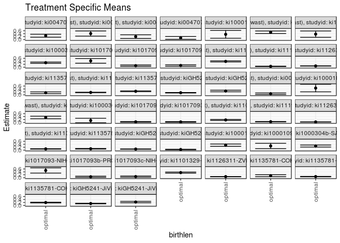

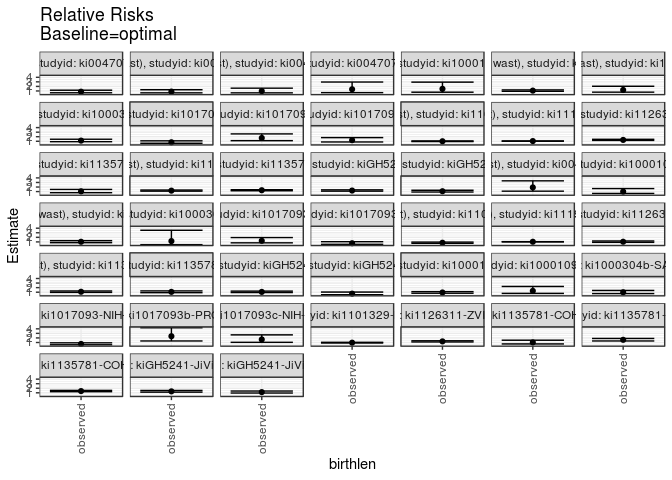

## Results Table

### Parameter: TSM

| agecat | studyid | country | intervention_level | baseline_level | estimate | ci_lower | ci_upper |
| --- | --- | --- | --- | --- | --- | --- | --- |
| 0-24 months (no birth wast) | ki0047075b-MAL-ED | BANGLADESH | optimal | NA | 0.2629592 | 0.1616935 | 0.3642249 |
| 0-24 months (no birth wast) | ki0047075b-MAL-ED | INDIA | optimal | NA | 0.4082611 | 0.2337864 | 0.5827358 |
| 0-24 months (no birth wast) | ki0047075b-MAL-ED | NEPAL | optimal | NA | 0.2024078 | 0.0788053 | 0.3260102 |
| 0-24 months (no birth wast) | ki0047075b-MAL-ED | SOUTH AFRICA | optimal | NA | 0.1142582 | 0.0193310 | 0.2091854 |
| 0-24 months (no birth wast) | ki1000108-CMC-V-BCS-2002 | INDIA | optimal | NA | 0.3556309 | 0.0911974 | 0.6200643 |
| 0-24 months (no birth wast) | ki1000108-IRC | INDIA | optimal | NA | 0.4938739 | 0.4074806 | 0.5802672 |
| 0-24 months (no birth wast) | ki1000109-EE | PAKISTAN | optimal | NA | 0.3694149 | 0.1564451 | 0.5823848 |
| 0-24 months (no birth wast) | ki1000304b-SAS-CompFeed | INDIA | optimal | NA | 0.3068778 | 0.2641003 | 0.3496553 |
| 0-24 months (no birth wast) | ki1017093-NIH-Birth | BANGLADESH | optimal | NA | 0.4308523 | 0.2733665 | 0.5883380 |
| 0-24 months (no birth wast) | ki1017093b-PROVIDE | BANGLADESH | optimal | NA | 0.1031048 | 0.0562282 | 0.1499813 |
| 0-24 months (no birth wast) | ki1017093c-NIH-Crypto | BANGLADESH | optimal | NA | 0.1158490 | 0.0672418 | 0.1644562 |
| 0-24 months (no birth wast) | ki1101329-Keneba | GAMBIA | optimal | NA | 0.3932779 | 0.3554445 | 0.4311114 |
| 0-24 months (no birth wast) | ki1119695-PROBIT | BELARUS | optimal | NA | 0.0587960 | 0.0448343 | 0.0727578 |
| 0-24 months (no birth wast) | ki1126311-ZVITAMBO | ZIMBABWE | optimal | NA | 0.0842499 | 0.0751776 | 0.0933222 |
| 0-24 months (no birth wast) | ki1135781-COHORTS | GUATEMALA | optimal | NA | 0.1420677 | 0.0825140 | 0.2016215 |
| 0-24 months (no birth wast) | ki1135781-COHORTS | INDIA | optimal | NA | 0.1623753 | 0.1438474 | 0.1809031 |
| 0-24 months (no birth wast) | ki1135781-COHORTS | PHILIPPINES | optimal | NA | 0.2409505 | 0.2156495 | 0.2662514 |
| 0-24 months (no birth wast) | kiGH5241-JiVitA-3 | BANGLADESH | optimal | NA | 0.1428696 | 0.1251510 | 0.1605881 |
| 0-24 months (no birth wast) | kiGH5241-JiVitA-4 | BANGLADESH | optimal | NA | 0.2588991 | 0.2058067 | 0.3119915 |
| 0-6 months (no birth wast) | ki0047075b-MAL-ED | INDIA | optimal | NA | 0.0766917 | 0.0250438 | 0.1283395 |
| 0-6 months (no birth wast) | ki1000108-CMC-V-BCS-2002 | INDIA | optimal | NA | 0.4589623 | 0.2036663 | 0.7142582 |
| 0-6 months (no birth wast) | ki1000108-IRC | INDIA | optimal | NA | 0.3413044 | 0.2543546 | 0.4282543 |
| 0-6 months (no birth wast) | ki1000304b-SAS-CompFeed | INDIA | optimal | NA | 0.1329218 | -0.0225750 | 0.2884185 |
| 0-6 months (no birth wast) | ki1017093b-PROVIDE | BANGLADESH | optimal | NA | 0.0425728 | 0.0188872 | 0.0662584 |
| 0-6 months (no birth wast) | ki1017093c-NIH-Crypto | BANGLADESH | optimal | NA | 0.0381279 | 0.0160669 | 0.0601889 |
| 0-6 months (no birth wast) | ki1101329-Keneba | GAMBIA | optimal | NA | 0.1732945 | 0.1389465 | 0.2076425 |
| 0-6 months (no birth wast) | ki1119695-PROBIT | BELARUS | optimal | NA | 0.0536002 | 0.0398301 | 0.0673703 |
| 0-6 months (no birth wast) | ki1126311-ZVITAMBO | ZIMBABWE | optimal | NA | 0.0364737 | 0.0301028 | 0.0428446 |
| 0-6 months (no birth wast) | ki1135781-COHORTS | INDIA | optimal | NA | 0.0827543 | 0.0692421 | 0.0962665 |
| 0-6 months (no birth wast) | ki1135781-COHORTS | PHILIPPINES | optimal | NA | 0.0915188 | 0.0725693 | 0.1104683 |
| 0-6 months (no birth wast) | kiGH5241-JiVitA-3 | BANGLADESH | optimal | NA | 0.0714714 | 0.0600099 | 0.0829329 |
| 0-6 months (no birth wast) | kiGH5241-JiVitA-4 | BANGLADESH | optimal | NA | 0.0405585 | 0.0202349 | 0.0608821 |
| 6-24 months | ki1000108-IRC | INDIA | optimal | NA | 0.3371509 | 0.2592864 | 0.4150153 |
| 6-24 months | ki1000109-EE | PAKISTAN | optimal | NA | 0.2828157 | 0.1008669 | 0.4647646 |
| 6-24 months | ki1000304b-SAS-CompFeed | INDIA | optimal | NA | 0.2771671 | 0.2084429 | 0.3458914 |
| 6-24 months | ki1017093-NIH-Birth | BANGLADESH | optimal | NA | 0.4950731 | 0.3172664 | 0.6728797 |
| 6-24 months | ki1017093b-PROVIDE | BANGLADESH | optimal | NA | 0.0677214 | 0.0261804 | 0.1092625 |
| 6-24 months | ki1017093c-NIH-Crypto | BANGLADESH | optimal | NA | 0.0790253 | 0.0380860 | 0.1199647 |
| 6-24 months | ki1101329-Keneba | GAMBIA | optimal | NA | 0.3511274 | 0.3118968 | 0.3903580 |
| 6-24 months | ki1126311-ZVITAMBO | ZIMBABWE | optimal | NA | 0.0754559 | 0.0662084 | 0.0847034 |
| 6-24 months | ki1135781-COHORTS | GUATEMALA | optimal | NA | 0.1399517 | 0.0737887 | 0.2061146 |
| 6-24 months | ki1135781-COHORTS | INDIA | optimal | NA | 0.0780362 | 0.0636301 | 0.0924424 |
| 6-24 months | ki1135781-COHORTS | PHILIPPINES | optimal | NA | 0.1932662 | 0.1694410 | 0.2170914 |
| 6-24 months | kiGH5241-JiVitA-3 | BANGLADESH | optimal | NA | 0.1255290 | 0.1063490 | 0.1447091 |
| 6-24 months | kiGH5241-JiVitA-4 | BANGLADESH | optimal | NA | 0.2284261 | 0.1785210 | 0.2783312 |

### Parameter: E(Y)

| agecat | studyid | country | intervention_level | baseline_level | estimate | ci_lower | ci_upper |
| --- | --- | --- | --- | --- | --- | --- | --- |
| 0-24 months (no birth wast) | ki0047075b-MAL-ED | BANGLADESH | observed | NA | 0.2204724 | 0.1693889 | 0.2715560 |
| 0-24 months (no birth wast) | ki0047075b-MAL-ED | INDIA | observed | NA | 0.3517588 | 0.2852458 | 0.4182718 |
| 0-24 months (no birth wast) | ki0047075b-MAL-ED | NEPAL | observed | NA | 0.1976744 | 0.1379846 | 0.2573643 |
| 0-24 months (no birth wast) | ki0047075b-MAL-ED | SOUTH AFRICA | observed | NA | 0.1563786 | 0.1106168 | 0.2021404 |
| 0-24 months (no birth wast) | ki1000108-CMC-V-BCS-2002 | INDIA | observed | NA | 0.5196078 | 0.4221710 | 0.6170447 |
| 0-24 months (no birth wast) | ki1000108-IRC | INDIA | observed | NA | 0.5307692 | 0.4811763 | 0.5803621 |
| 0-24 months (no birth wast) | ki1000109-EE | PAKISTAN | observed | NA | 0.4505495 | 0.3477567 | 0.5533422 |
| 0-24 months (no birth wast) | ki1000304b-SAS-CompFeed | INDIA | observed | NA | 0.3508772 | 0.2566771 | 0.4450772 |
| 0-24 months (no birth wast) | ki1017093-NIH-Birth | BANGLADESH | observed | NA | 0.3364929 | 0.2725858 | 0.4004000 |
| 0-24 months (no birth wast) | ki1017093b-PROVIDE | BANGLADESH | observed | NA | 0.1775837 | 0.1489858 | 0.2061816 |
| 0-24 months (no birth wast) | ki1017093c-NIH-Crypto | BANGLADESH | observed | NA | 0.1432361 | 0.1182149 | 0.1682572 |
| 0-24 months (no birth wast) | ki1101329-Keneba | GAMBIA | observed | NA | 0.3939198 | 0.3695556 | 0.4182840 |
| 0-24 months (no birth wast) | ki1119695-PROBIT | BELARUS | observed | NA | 0.0612597 | 0.0474556 | 0.0750638 |
| 0-24 months (no birth wast) | ki1126311-ZVITAMBO | ZIMBABWE | observed | NA | 0.1091366 | 0.1036313 | 0.1146419 |
| 0-24 months (no birth wast) | ki1135781-COHORTS | GUATEMALA | observed | NA | 0.1492147 | 0.1134379 | 0.1849914 |
| 0-24 months (no birth wast) | ki1135781-COHORTS | INDIA | observed | NA | 0.1954545 | 0.1857233 | 0.2051858 |
| 0-24 months (no birth wast) | ki1135781-COHORTS | PHILIPPINES | observed | NA | 0.3118390 | 0.2950654 | 0.3286125 |
| 0-24 months (no birth wast) | kiGH5241-JiVitA-3 | BANGLADESH | observed | NA | 0.1748553 | 0.1668952 | 0.1828153 |
| 0-24 months (no birth wast) | kiGH5241-JiVitA-4 | BANGLADESH | observed | NA | 0.2783945 | 0.2477970 | 0.3089921 |
| 0-6 months (no birth wast) | ki0047075b-MAL-ED | INDIA | observed | NA | 0.1464646 | 0.0970913 | 0.1958379 |
| 0-6 months (no birth wast) | ki1000108-CMC-V-BCS-2002 | INDIA | observed | NA | 0.4545455 | 0.3559622 | 0.5531287 |
| 0-6 months (no birth wast) | ki1000108-IRC | INDIA | observed | NA | 0.3494624 | 0.3009450 | 0.3979798 |
| 0-6 months (no birth wast) | ki1000304b-SAS-CompFeed | INDIA | observed | NA | 0.1562500 | 0.0949206 | 0.2175794 |
| 0-6 months (no birth wast) | ki1017093b-PROVIDE | BANGLADESH | observed | NA | 0.0527086 | 0.0359384 | 0.0694789 |
| 0-6 months (no birth wast) | ki1017093c-NIH-Crypto | BANGLADESH | observed | NA | 0.0267023 | 0.0151493 | 0.0382553 |
| 0-6 months (no birth wast) | ki1101329-Keneba | GAMBIA | observed | NA | 0.1404087 | 0.1229206 | 0.1578968 |
| 0-6 months (no birth wast) | ki1119695-PROBIT | BELARUS | observed | NA | 0.0550194 | 0.0412334 | 0.0688054 |
| 0-6 months (no birth wast) | ki1126311-ZVITAMBO | ZIMBABWE | observed | NA | 0.0376159 | 0.0341115 | 0.0411202 |
| 0-6 months (no birth wast) | ki1135781-COHORTS | INDIA | observed | NA | 0.0905846 | 0.0832504 | 0.0979189 |
| 0-6 months (no birth wast) | ki1135781-COHORTS | PHILIPPINES | observed | NA | 0.0980256 | 0.0871772 | 0.1088741 |
| 0-6 months (no birth wast) | kiGH5241-JiVitA-3 | BANGLADESH | observed | NA | 0.0759915 | 0.0706126 | 0.0813703 |
| 0-6 months (no birth wast) | kiGH5241-JiVitA-4 | BANGLADESH | observed | NA | 0.0275801 | 0.0176087 | 0.0375515 |
| 6-24 months | ki1000108-IRC | INDIA | observed | NA | 0.3145780 | 0.2684931 | 0.3606629 |
| 6-24 months | ki1000109-EE | PAKISTAN | observed | NA | 0.3636364 | 0.2625541 | 0.4647186 |
| 6-24 months | ki1000304b-SAS-CompFeed | INDIA | observed | NA | 0.2720930 | 0.2192075 | 0.3249786 |
| 6-24 months | ki1017093-NIH-Birth | BANGLADESH | observed | NA | 0.3388889 | 0.2695483 | 0.4082295 |
| 6-24 months | ki1017093b-PROVIDE | BANGLADESH | observed | NA | 0.1609756 | 0.1319065 | 0.1900447 |
| 6-24 months | ki1017093c-NIH-Crypto | BANGLADESH | observed | NA | 0.1315068 | 0.1069744 | 0.1560393 |
| 6-24 months | ki1101329-Keneba | GAMBIA | observed | NA | 0.3369200 | 0.3128882 | 0.3609517 |
| 6-24 months | ki1126311-ZVITAMBO | ZIMBABWE | observed | NA | 0.0937559 | 0.0881988 | 0.0993131 |
| 6-24 months | ki1135781-COHORTS | GUATEMALA | observed | NA | 0.1420290 | 0.1051403 | 0.1789177 |
| 6-24 months | ki1135781-COHORTS | INDIA | observed | NA | 0.1238450 | 0.1156244 | 0.1320657 |
| 6-24 months | ki1135781-COHORTS | PHILIPPINES | observed | NA | 0.2665953 | 0.2502200 | 0.2829706 |
| 6-24 months | kiGH5241-JiVitA-3 | BANGLADESH | observed | NA | 0.1651770 | 0.1558486 | 0.1745053 |
| 6-24 months | kiGH5241-JiVitA-4 | BANGLADESH | observed | NA | 0.2623090 | 0.2322804 | 0.2923376 |

### Parameter: RR

| agecat | studyid | country | intervention_level | baseline_level | estimate | ci_lower | ci_upper |
| --- | --- | --- | --- | --- | --- | --- | --- |
| 0-24 months (no birth wast) | ki0047075b-MAL-ED | BANGLADESH | observed | optimal | 0.8384284 | 0.6015813 | 1.1685241 |
| 0-24 months (no birth wast) | ki0047075b-MAL-ED | INDIA | observed | optimal | 0.8616025 | 0.5850803 | 1.2688154 |
| 0-24 months (no birth wast) | ki0047075b-MAL-ED | NEPAL | observed | optimal | 0.9766148 | 0.5904929 | 1.6152210 |
| 0-24 months (no birth wast) | ki0047075b-MAL-ED | SOUTH AFRICA | observed | optimal | 1.3686421 | 0.6326167 | 2.9610050 |
| 0-24 months (no birth wast) | ki1000108-CMC-V-BCS-2002 | INDIA | observed | optimal | 1.4610875 | 0.7265976 | 2.9380453 |
| 0-24 months (no birth wast) | ki1000108-IRC | INDIA | observed | optimal | 1.0747060 | 0.9343256 | 1.2361782 |
| 0-24 months (no birth wast) | ki1000109-EE | PAKISTAN | observed | optimal | 1.2196297 | 0.7322191 | 2.0314911 |
| 0-24 months (no birth wast) | ki1000304b-SAS-CompFeed | INDIA | observed | optimal | 1.1433775 | 0.9047554 | 1.4449343 |
| 0-24 months (no birth wast) | ki1017093-NIH-Birth | BANGLADESH | observed | optimal | 0.7809936 | 0.5590545 | 1.0910404 |
| 0-24 months (no birth wast) | ki1017093b-PROVIDE | BANGLADESH | observed | optimal | 1.7223614 | 1.1326724 | 2.6190527 |
| 0-24 months (no birth wast) | ki1017093c-NIH-Crypto | BANGLADESH | observed | optimal | 1.2364035 | 0.8472113 | 1.8043828 |
| 0-24 months (no birth wast) | ki1101329-Keneba | GAMBIA | observed | optimal | 1.0016321 | 0.9307864 | 1.0778701 |
| 0-24 months (no birth wast) | ki1119695-PROBIT | BELARUS | observed | optimal | 1.0419018 | 1.0145502 | 1.0699908 |
| 0-24 months (no birth wast) | ki1126311-ZVITAMBO | ZIMBABWE | observed | optimal | 1.2953915 | 1.1793613 | 1.4228371 |
| 0-24 months (no birth wast) | ki1135781-COHORTS | GUATEMALA | observed | optimal | 1.0503064 | 0.7523492 | 1.4662651 |
| 0-24 months (no birth wast) | ki1135781-COHORTS | INDIA | observed | optimal | 1.2037212 | 1.0869251 | 1.3330678 |
| 0-24 months (no birth wast) | ki1135781-COHORTS | PHILIPPINES | observed | optimal | 1.2942036 | 1.1865442 | 1.4116314 |
| 0-24 months (no birth wast) | kiGH5241-JiVitA-3 | BANGLADESH | observed | optimal | 1.2238805 | 1.0894279 | 1.3749267 |
| 0-24 months (no birth wast) | kiGH5241-JiVitA-4 | BANGLADESH | observed | optimal | 1.0753011 | 0.8973428 | 1.2885516 |
| 0-6 months (no birth wast) | ki0047075b-MAL-ED | INDIA | observed | optimal | 1.9097857 | 1.0855128 | 3.3599618 |
| 0-6 months (no birth wast) | ki1000108-CMC-V-BCS-2002 | INDIA | observed | optimal | 0.9903765 | 0.5923869 | 1.6557518 |
| 0-6 months (no birth wast) | ki1000108-IRC | INDIA | observed | optimal | 1.0239022 | 0.8290368 | 1.2645708 |
| 0-6 months (no birth wast) | ki1000304b-SAS-CompFeed | INDIA | observed | optimal | 1.1755034 | 0.3896488 | 3.5462917 |
| 0-6 months (no birth wast) | ki1017093b-PROVIDE | BANGLADESH | observed | optimal | 1.2380828 | 0.7869813 | 1.9477576 |
| 0-6 months (no birth wast) | ki1017093c-NIH-Crypto | BANGLADESH | observed | optimal | 0.7003348 | 0.4735918 | 1.0356362 |
| 0-6 months (no birth wast) | ki1101329-Keneba | GAMBIA | observed | optimal | 0.8102318 | 0.6863796 | 0.9564322 |
| 0-6 months (no birth wast) | ki1119695-PROBIT | BELARUS | observed | optimal | 1.0264781 | 1.0016852 | 1.0518846 |
| 0-6 months (no birth wast) | ki1126311-ZVITAMBO | ZIMBABWE | observed | optimal | 1.0313163 | 0.8902830 | 1.1946912 |
| 0-6 months (no birth wast) | ki1135781-COHORTS | INDIA | observed | optimal | 1.0946218 | 0.9509594 | 1.2599873 |
| 0-6 months (no birth wast) | ki1135781-COHORTS | PHILIPPINES | observed | optimal | 1.0710983 | 0.8938433 | 1.2835041 |
| 0-6 months (no birth wast) | kiGH5241-JiVitA-3 | BANGLADESH | observed | optimal | 1.0632425 | 0.9183325 | 1.2310187 |
| 0-6 months (no birth wast) | kiGH5241-JiVitA-4 | BANGLADESH | observed | optimal | 0.6800071 | 0.4504216 | 1.0266153 |
| 6-24 months | ki1000108-IRC | INDIA | observed | optimal | 0.9330482 | 0.7746454 | 1.1238418 |
| 6-24 months | ki1000109-EE | PAKISTAN | observed | optimal | 1.2857713 | 0.7335326 | 2.2537620 |
| 6-24 months | ki1000304b-SAS-CompFeed | INDIA | observed | optimal | 0.9816929 | 0.6984952 | 1.3797103 |
| 6-24 months | ki1017093-NIH-Birth | BANGLADESH | observed | optimal | 0.6845230 | 0.5048703 | 0.9281030 |
| 6-24 months | ki1017093b-PROVIDE | BANGLADESH | observed | optimal | 2.3770257 | 1.3324961 | 4.2403509 |
| 6-24 months | ki1017093c-NIH-Crypto | BANGLADESH | observed | optimal | 1.6641103 | 1.0362055 | 2.6725038 |
| 6-24 months | ki1101329-Keneba | GAMBIA | observed | optimal | 0.9595377 | 0.8804087 | 1.0457787 |
| 6-24 months | ki1126311-ZVITAMBO | ZIMBABWE | observed | optimal | 1.2425257 | 1.1175074 | 1.3815300 |
| 6-24 months | ki1135781-COHORTS | GUATEMALA | observed | optimal | 1.0148431 | 0.6844026 | 1.5048255 |
| 6-24 months | ki1135781-COHORTS | INDIA | observed | optimal | 1.5870193 | 1.3380837 | 1.8822666 |
| 6-24 months | ki1135781-COHORTS | PHILIPPINES | observed | optimal | 1.3794199 | 1.2435609 | 1.5301216 |
| 6-24 months | kiGH5241-JiVitA-3 | BANGLADESH | observed | optimal | 1.3158467 | 1.1457231 | 1.5112311 |
| 6-24 months | kiGH5241-JiVitA-4 | BANGLADESH | observed | optimal | 1.1483319 | 0.9469914 | 1.3924795 |

### Parameter: PAR

| agecat | studyid | country | intervention_level | baseline_level | estimate | ci_lower | ci_upper |
| --- | --- | --- | --- | --- | --- | --- | --- |
| 0-24 months (no birth wast) | ki0047075b-MAL-ED | BANGLADESH | optimal | NA | -0.0424867 | -0.1293373 | 0.0443638 |
| 0-24 months (no birth wast) | ki0047075b-MAL-ED | INDIA | optimal | NA | -0.0565023 | -0.2146657 | 0.1016610 |
| 0-24 months (no birth wast) | ki0047075b-MAL-ED | NEPAL | optimal | NA | -0.0047333 | -0.1067161 | 0.0972494 |
| 0-24 months (no birth wast) | ki0047075b-MAL-ED | SOUTH AFRICA | optimal | NA | 0.0421204 | -0.0466654 | 0.1309062 |
| 0-24 months (no birth wast) | ki1000108-CMC-V-BCS-2002 | INDIA | optimal | NA | 0.1639770 | -0.0828624 | 0.4108163 |
| 0-24 months (no birth wast) | ki1000108-IRC | INDIA | optimal | NA | 0.0368953 | -0.0320215 | 0.1058121 |
| 0-24 months (no birth wast) | ki1000109-EE | PAKISTAN | optimal | NA | 0.0811345 | -0.1066686 | 0.2689376 |
| 0-24 months (no birth wast) | ki1000304b-SAS-CompFeed | INDIA | optimal | NA | 0.0439994 | -0.0381602 | 0.1261589 |
| 0-24 months (no birth wast) | ki1017093-NIH-Birth | BANGLADESH | optimal | NA | -0.0943594 | -0.2375052 | 0.0487865 |
| 0-24 months (no birth wast) | ki1017093b-PROVIDE | BANGLADESH | optimal | NA | 0.0744789 | 0.0300724 | 0.1188854 |
| 0-24 months (no birth wast) | ki1017093c-NIH-Crypto | BANGLADESH | optimal | NA | 0.0273871 | -0.0165708 | 0.0713450 |
| 0-24 months (no birth wast) | ki1101329-Keneba | GAMBIA | optimal | NA | 0.0006419 | -0.0282074 | 0.0294911 |
| 0-24 months (no birth wast) | ki1119695-PROBIT | BELARUS | optimal | NA | 0.0024637 | 0.0010338 | 0.0038935 |
| 0-24 months (no birth wast) | ki1126311-ZVITAMBO | ZIMBABWE | optimal | NA | 0.0248867 | 0.0169138 | 0.0328596 |
| 0-24 months (no birth wast) | ki1135781-COHORTS | GUATEMALA | optimal | NA | 0.0071469 | -0.0402089 | 0.0545027 |
| 0-24 months (no birth wast) | ki1135781-COHORTS | INDIA | optimal | NA | 0.0330793 | 0.0164448 | 0.0497138 |
| 0-24 months (no birth wast) | ki1135781-COHORTS | PHILIPPINES | optimal | NA | 0.0708885 | 0.0498554 | 0.0919216 |
| 0-24 months (no birth wast) | kiGH5241-JiVitA-3 | BANGLADESH | optimal | NA | 0.0319857 | 0.0152637 | 0.0487077 |
| 0-24 months (no birth wast) | kiGH5241-JiVitA-4 | BANGLADESH | optimal | NA | 0.0194954 | -0.0275413 | 0.0665321 |
| 0-6 months (no birth wast) | ki0047075b-MAL-ED | INDIA | optimal | NA | 0.0697730 | 0.0216130 | 0.1179330 |
| 0-6 months (no birth wast) | ki1000108-CMC-V-BCS-2002 | INDIA | optimal | NA | -0.0044168 | -0.2402835 | 0.2314499 |
| 0-6 months (no birth wast) | ki1000108-IRC | INDIA | optimal | NA | 0.0081579 | -0.0638839 | 0.0801998 |
| 0-6 months (no birth wast) | ki1000304b-SAS-CompFeed | INDIA | optimal | NA | 0.0233282 | -0.1237809 | 0.1704374 |
| 0-6 months (no birth wast) | ki1017093b-PROVIDE | BANGLADESH | optimal | NA | 0.0101358 | -0.0093892 | 0.0296609 |
| 0-6 months (no birth wast) | ki1017093c-NIH-Crypto | BANGLADESH | optimal | NA | -0.0114256 | -0.0270637 | 0.0042125 |
| 0-6 months (no birth wast) | ki1101329-Keneba | GAMBIA | optimal | NA | -0.0328858 | -0.0615538 | -0.0042177 |
| 0-6 months (no birth wast) | ki1119695-PROBIT | BELARUS | optimal | NA | 0.0014192 | 0.0001368 | 0.0027017 |
| 0-6 months (no birth wast) | ki1126311-ZVITAMBO | ZIMBABWE | optimal | NA | 0.0011422 | -0.0042216 | 0.0065060 |
| 0-6 months (no birth wast) | ki1135781-COHORTS | INDIA | optimal | NA | 0.0078304 | -0.0038212 | 0.0194819 |
| 0-6 months (no birth wast) | ki1135781-COHORTS | PHILIPPINES | optimal | NA | 0.0065068 | -0.0101032 | 0.0231168 |
| 0-6 months (no birth wast) | kiGH5241-JiVitA-3 | BANGLADESH | optimal | NA | 0.0045200 | -0.0059685 | 0.0150086 |
| 0-6 months (no birth wast) | kiGH5241-JiVitA-4 | BANGLADESH | optimal | NA | -0.0129784 | -0.0295672 | 0.0036103 |
| 6-24 months | ki1000108-IRC | INDIA | optimal | NA | -0.0225729 | -0.0852212 | 0.0400755 |
| 6-24 months | ki1000109-EE | PAKISTAN | optimal | NA | 0.0808206 | -0.0779398 | 0.2395810 |
| 6-24 months | ki1000304b-SAS-CompFeed | INDIA | optimal | NA | -0.0050741 | -0.0987239 | 0.0885757 |
| 6-24 months | ki1017093-NIH-Birth | BANGLADESH | optimal | NA | -0.1561842 | -0.3088471 | -0.0035213 |
| 6-24 months | ki1017093b-PROVIDE | BANGLADESH | optimal | NA | 0.0932542 | 0.0512387 | 0.1352696 |
| 6-24 months | ki1017093c-NIH-Crypto | BANGLADESH | optimal | NA | 0.0524815 | 0.0142804 | 0.0906826 |
| 6-24 months | ki1101329-Keneba | GAMBIA | optimal | NA | -0.0142074 | -0.0444434 | 0.0160285 |
| 6-24 months | ki1126311-ZVITAMBO | ZIMBABWE | optimal | NA | 0.0183000 | 0.0102474 | 0.0263526 |
| 6-24 months | ki1135781-COHORTS | GUATEMALA | optimal | NA | 0.0020773 | -0.0530561 | 0.0572107 |
| 6-24 months | ki1135781-COHORTS | INDIA | optimal | NA | 0.0458088 | 0.0322255 | 0.0593921 |
| 6-24 months | ki1135781-COHORTS | PHILIPPINES | optimal | NA | 0.0733291 | 0.0530242 | 0.0936339 |
| 6-24 months | kiGH5241-JiVitA-3 | BANGLADESH | optimal | NA | 0.0396479 | 0.0222666 | 0.0570292 |
| 6-24 months | kiGH5241-JiVitA-4 | BANGLADESH | optimal | NA | 0.0338829 | -0.0105441 | 0.0783099 |

### Parameter: PAF

| agecat | studyid | country | intervention_level | baseline_level | estimate | ci_lower | ci_upper |
| --- | --- | --- | --- | --- | --- | --- | --- |
| 0-24 months (no birth wast) | ki0047075b-MAL-ED | BANGLADESH | optimal | NA | -0.1927076 | -0.6622858 | 0.1442196 |
| 0-24 months (no birth wast) | ki0047075b-MAL-ED | INDIA | optimal | NA | -0.1606280 | -0.7091672 | 0.2118633 |
| 0-24 months (no birth wast) | ki0047075b-MAL-ED | NEPAL | optimal | NA | -0.0239451 | -0.6935005 | 0.3808897 |
| 0-24 months (no birth wast) | ki0047075b-MAL-ED | SOUTH AFRICA | optimal | NA | 0.2693488 | -0.5807360 | 0.6622768 |
| 0-24 months (no birth wast) | ki1000108-CMC-V-BCS-2002 | INDIA | optimal | NA | 0.3155783 | -0.3762775 | 0.6596376 |
| 0-24 months (no birth wast) | ki1000108-IRC | INDIA | optimal | NA | 0.0695129 | -0.0702907 | 0.1910551 |
| 0-24 months (no birth wast) | ki1000109-EE | PAKISTAN | optimal | NA | 0.1800790 | -0.3657114 | 0.5077507 |
| 0-24 months (no birth wast) | ki1000304b-SAS-CompFeed | INDIA | optimal | NA | 0.1253982 | -0.1052711 | 0.3079270 |
| 0-24 months (no birth wast) | ki1017093-NIH-Birth | BANGLADESH | optimal | NA | -0.2804202 | -0.7887344 | 0.0834437 |
| 0-24 months (no birth wast) | ki1017093b-PROVIDE | BANGLADESH | optimal | NA | 0.4194018 | 0.1171322 | 0.6181826 |
| 0-24 months (no birth wast) | ki1017093c-NIH-Crypto | BANGLADESH | optimal | NA | 0.1912025 | -0.1803430 | 0.4457939 |
| 0-24 months (no birth wast) | ki1101329-Keneba | GAMBIA | optimal | NA | 0.0016294 | -0.0743604 | 0.0722444 |
| 0-24 months (no birth wast) | ki1119695-PROBIT | BELARUS | optimal | NA | 0.0402166 | 0.0143415 | 0.0654125 |
| 0-24 months (no birth wast) | ki1126311-ZVITAMBO | ZIMBABWE | optimal | NA | 0.2280326 | 0.1520834 | 0.2971789 |
| 0-24 months (no birth wast) | ki1135781-COHORTS | GUATEMALA | optimal | NA | 0.0478969 | -0.3291699 | 0.3179951 |
| 0-24 months (no birth wast) | ki1135781-COHORTS | INDIA | optimal | NA | 0.1692429 | 0.0799734 | 0.2498506 |
| 0-24 months (no birth wast) | ki1135781-COHORTS | PHILIPPINES | optimal | NA | 0.2273241 | 0.1572164 | 0.2915998 |
| 0-24 months (no birth wast) | kiGH5241-JiVitA-3 | BANGLADESH | optimal | NA | 0.1829268 | 0.0820870 | 0.2726885 |
| 0-24 months (no birth wast) | kiGH5241-JiVitA-4 | BANGLADESH | optimal | NA | 0.0700279 | -0.1144013 | 0.2239349 |
| 0-6 months (no birth wast) | ki0047075b-MAL-ED | INDIA | optimal | NA | 0.4763810 | 0.0787764 | 0.7023776 |
| 0-6 months (no birth wast) | ki1000108-CMC-V-BCS-2002 | INDIA | optimal | NA | -0.0097170 | -0.6880859 | 0.3960447 |
| 0-6 months (no birth wast) | ki1000108-IRC | INDIA | optimal | NA | 0.0233443 | -0.2062190 | 0.2092179 |
| 0-6 months (no birth wast) | ki1000304b-SAS-CompFeed | INDIA | optimal | NA | 0.1493006 | -1.5664138 | 0.7180153 |
| 0-6 months (no birth wast) | ki1017093b-PROVIDE | BANGLADESH | optimal | NA | 0.1922995 | -0.2706782 | 0.4865891 |
| 0-6 months (no birth wast) | ki1017093c-NIH-Crypto | BANGLADESH | optimal | NA | -0.4278885 | -1.1115231 | 0.0344099 |
| 0-6 months (no birth wast) | ki1101329-Keneba | GAMBIA | optimal | NA | -0.2342147 | -0.4569197 | -0.0455525 |
| 0-6 months (no birth wast) | ki1119695-PROBIT | BELARUS | optimal | NA | 0.0257951 | 0.0016824 | 0.0493254 |
| 0-6 months (no birth wast) | ki1126311-ZVITAMBO | ZIMBABWE | optimal | NA | 0.0303653 | -0.1232383 | 0.1629636 |
| 0-6 months (no birth wast) | ki1135781-COHORTS | INDIA | optimal | NA | 0.0864424 | -0.0515696 | 0.2063412 |
| 0-6 months (no birth wast) | ki1135781-COHORTS | PHILIPPINES | optimal | NA | 0.0663789 | -0.1187643 | 0.2208829 |
| 0-6 months (no birth wast) | kiGH5241-JiVitA-3 | BANGLADESH | optimal | NA | 0.0594808 | -0.0889302 | 0.1876647 |
| 0-6 months (no birth wast) | kiGH5241-JiVitA-4 | BANGLADESH | optimal | NA | -0.4705728 | -1.2201422 | 0.0259253 |
| 6-24 months | ki1000108-IRC | INDIA | optimal | NA | -0.0717560 | -0.2909132 | 0.1101950 |
| 6-24 months | ki1000109-EE | PAKISTAN | optimal | NA | 0.2222567 | -0.3632659 | 0.5562974 |
| 6-24 months | ki1000304b-SAS-CompFeed | INDIA | optimal | NA | -0.0186485 | -0.4316490 | 0.2752102 |
| 6-24 months | ki1017093-NIH-Birth | BANGLADESH | optimal | NA | -0.4608714 | -0.9807067 | -0.0774666 |
| 6-24 months | ki1017093b-PROVIDE | BANGLADESH | optimal | NA | 0.5793062 | 0.2495288 | 0.7641705 |
| 6-24 months | ki1017093c-NIH-Crypto | BANGLADESH | optimal | NA | 0.3990783 | 0.0349405 | 0.6258190 |
| 6-24 months | ki1101329-Keneba | GAMBIA | optimal | NA | -0.0421685 | -0.1358362 | 0.0437748 |
| 6-24 months | ki1126311-ZVITAMBO | ZIMBABWE | optimal | NA | 0.1951876 | 0.1051513 | 0.2761649 |
| 6-24 months | ki1135781-COHORTS | GUATEMALA | optimal | NA | 0.0146260 | -0.4611283 | 0.3354711 |
| 6-24 months | ki1135781-COHORTS | INDIA | optimal | NA | 0.3698880 | 0.2526626 | 0.4687256 |
| 6-24 months | ki1135781-COHORTS | PHILIPPINES | optimal | NA | 0.2750576 | 0.1958576 | 0.3464572 |
| 6-24 months | kiGH5241-JiVitA-3 | BANGLADESH | optimal | NA | 0.2400330 | 0.1271888 | 0.3382879 |
| 6-24 months | kiGH5241-JiVitA-4 | BANGLADESH | optimal | NA | 0.1291716 | -0.0559757 | 0.2818566 |